# Estimate Trophic Position - One Source Model - Multiple Groups

## Our Objectives

The purpose of this vignette is to learn how to estimate trophic position for multiple species or groups using stable isotope data ($\delta^{13}C$ and $\delta^{15}N$). We can estimate trophic position using a one source model based on equations from Post 2002.

## Trophic Position Model

The equation for a one source model consists of the following:

$$\text{Trophic Position} = \lambda + \frac{(\delta^{15}N_c -
\delta^{15}N_b)}{\Delta N}$$

Where $\lambda$ is the trophic position of the baseline (e.g., `2`), $\delta^{15}N_c$ is the $\delta^{15}N$ of the consumer, $\delta^{15}N_b$ is the mean $\delta^{15}N$ of the baseline, and $\Delta N$ is the trophic enrichment factor (e.g., 3.4).

To use this model with a Bayesian framework, we need to rearrange this equation to the following:

$$\delta^{15}N_c = \delta^{15}N_b + \Delta N \times (\text{Trophic
Position} - \lambda)$$

The function `one_source_model()` uses this rearranged equation.

## Vignette structure

First we need to organize the data prior to running the model. To do this work we will use [{dplyr}](https://dplyr.tidyverse.org/) and [{tidyr}](https://tidyr.tidyverse.org/) but we could also use [{data.table}](https://rdatatable.gitlab.io/data.table/).

When running the model we will use [{trps}](https://benjaminhlina.github.io/trps/) and [{brms}](https://paulbuerkner.com/brms/) and iterative processes provided by [{purrr}](https://purrr.tidyverse.org/).

Once we have run the model we will use [{bayesplot}](https://mc-stan.org/bayesplot/) to assess models and then extract posterior draws using [{tidybayes}](http://mjskay.github.io/tidybayes/). Posterior distributions will be plotted using [{ggplot2}](https://ggplot2.tidyverse.org/) and [{ggdist}](https://mjskay.github.io/ggdist/) with colours provided by [{viridis}](https://sjmgarnier.github.io/viridis/).

## Load packages

First we load all the packages needed to carry out the analysis.

```r
{
library(bayesplot)
library(brms)
library(dplyr)
library(ggplot2)
library(ggdist)
library(grid)
library(purrr)
library(tidybayes)
library(tidyr)
library(trps)
library(viridis)
}
```

## Working with multiple groups

In [{trps}](https://benjaminhlina.github.io/trps/) we have a data set that has consumer and baseline data already joined for two ecoregions (`combined_iso`) using the same methods in estimating trophic position - one source. Let’s look at this data frame.

### Organize data - multiple groups

```r
combined_iso
```

```
#> # A tibble: 117 × 13
#>       id common_name ecoregion      d13c  d15n d13c_b1 d15n_b1 d13c_b2 d15n_b2    c1    n1    c2    n2
#>    <int> <fct>       <fct>         <dbl> <dbl>   <dbl>   <dbl>   <dbl>   <dbl> <dbl> <dbl> <dbl> <dbl>
#>  1     1 Lake Trout  Anthropogenic -22.3  17.6   -20.3    8.85   -26.4    7.72 -21.3  8.14 -25.3  9.83
#>  2     2 Lake Trout  Anthropogenic -23.0  17.7   -20.1    8.77   -24.4    8.69 -21.3  8.14 -25.3  9.83
#>  3     3 Lake Trout  Anthropogenic -21.2  16.7   -20.3    8.85   -24.8    7.99 -21.3  8.14 -25.3  9.83
#>  4     4 Lake Trout  Anthropogenic -20.9  18.7   -20.1    8.77   -24.4    8.69 -21.3  8.14 -25.3  9.83
#>  5     5 Lake Trout  Anthropogenic -20.7  18.0   -20.5    8.38   -24.8    7.99 -21.3  8.14 -25.3  9.83
#>  6     6 Lake Trout  Anthropogenic -20.7  18.0   -20.1    8.34   -24.4    8.05 -21.3  8.14 -25.3  9.83
#>  7     7 Lake Trout  Anthropogenic -22.8  17.8   -19.7    8.04   -24.1    8.79 -21.3  8.14 -25.3  9.83
#>  8     8 Lake Trout  Anthropogenic -22.4  17.9   -20.1    8.56   -24.6   10.7  -21.3  8.14 -25.3  9.83
#>  9     9 Lake Trout  Anthropogenic -20.9  18.4   -18.7    8.95   -24.3   10.6  -21.3  8.14 -25.3  9.83
#> 10    10 Lake Trout  Anthropogenic -21.7  17.7   -20.8    9.28   -24.6   10.7  -21.3  8.14 -25.3  9.83
#> # ℹ 107 more rows
```

We can see that this data frame has isotope data for a second baseline (dreissenids; `d13c_b2` and `d15n_b2`) as well as the mean values for both baselines (`c1`-`n2`). These columns for the second baseline are useful when estimating trophic position using a two source model but we do not need them for this analysis and they can be removed.

We can also confirm that this data set has one species, lake trout.

```r
unique(combined_iso$common_name)
```

```
#> [1] Lake Trout
#> Levels: Lake Trout
```

collected from two ecoregions in Lake Ontario.

```r
unique(combined_iso$ecoregion)
```

```
#> [1] Anthropogenic Embayment
#> Levels: Anthropogenic Embayment
```

Let’s remove the columns we don’t need, `d13c_b2`, `d15n_b2`, `c2`, `n2`, and add $\lambda$ to the data frame (`l1`). To do so we make a `name` column that will be the two groups we have, `common_name` and `ecoregion` pasted together. We are doing this to make the iterative processes easier.

```r
combined_iso_update <- combined_iso %>%
  dplyr::select(-c(d13c_b2, d15n_b2, c2, n2)) %>%
  mutate(
    l1 = 2,
    name = paste(ecoregion, common_name, sep = "_")
  ) %>%
  dplyr::select(id, common_name, ecoregion, name, d13c:l1)
```

Let’s view our completed data set.

```r
combined_iso_update
```

```
#> # A tibble: 117 × 11
#>       id common_name ecoregion     name                      d13c  d15n d13c_b1 d15n_b1    c1    n1    l1
#>    <int> <fct>       <fct>         <chr>                    <dbl> <dbl>   <dbl>   <dbl> <dbl> <dbl> <dbl>
#>  1     1 Lake Trout  Anthropogenic Anthropogenic_Lake Trout -22.3  17.6   -20.3    8.85 -21.3  8.14     2
#>  2     2 Lake Trout  Anthropogenic Anthropogenic_Lake Trout -23.0  17.7   -20.1    8.77 -21.3  8.14     2
#>  3     3 Lake Trout  Anthropogenic Anthropogenic_Lake Trout -21.2  16.7   -20.3    8.85 -21.3  8.14     2
#>  4     4 Lake Trout  Anthropogenic Anthropogenic_Lake Trout -20.9  18.7   -20.1    8.77 -21.3  8.14     2
#>  5     5 Lake Trout  Anthropogenic Anthropogenic_Lake Trout -20.7  18.0   -20.5    8.38 -21.3  8.14     2
#>  6     6 Lake Trout  Anthropogenic Anthropogenic_Lake Trout -20.7  18.0   -20.1    8.34 -21.3  8.14     2
#>  7     7 Lake Trout  Anthropogenic Anthropogenic_Lake Trout -22.8  17.8   -19.7    8.04 -21.3  8.14     2
#>  8     8 Lake Trout  Anthropogenic Anthropogenic_Lake Trout -22.4  17.9   -20.1    8.56 -21.3  8.14     2
#>  9     9 Lake Trout  Anthropogenic Anthropogenic_Lake Trout -20.9  18.4   -18.7    8.95 -21.3  8.14     2
#> 10    10 Lake Trout  Anthropogenic Anthropogenic_Lake Trout -21.7  17.7   -20.8    9.28 -21.3  8.14     2
#> # ℹ 107 more rows
```

This example data is now ready to be analyzed.

## Estimate trophic position - multiple groups

We will use similar structure as before to model trophic position, however, we first `split()` the data into a list for all groups and then use `map()` from [{purrr}](https://purrr.tidyverse.org/) to run the model for each group.

You will notice that the `brm()` call is exactly the same as when we ran the model for one group. The only difference here is when using `map()`, the `data` argument in `brm()` needs to be replaced with `.x` to tell `brm()` where to get the data.

### Model - multiple groups

Let’s run the model!

```r
m1 <- combined_iso_update %>%
  split(.$name) %>%
  map( ~ brm(
    formula = one_source_model(),
    prior = one_source_priors(),
    stanvars = one_source_priors_params(),
    data = .x,
    family = gaussian(),
    chains = 2,
    iter = 4000,
    warmup = 1000,
    cores = 4,
    seed = 4,
    control = list(adapt_delta = 0.95)
  ),
  .progress = TRUE
  )
```

```
#>  ■■■■■■■■■■■■■■■■                  50% |  ETA: 27sCompiling Stan program...
#>
```

### Model output - multiple groups

Let’s look at the summary of both models.

```r
m1
```

```
#> $`Anthropogenic_Lake Trout`
#>  Family: gaussian
#>   Links: mu = identity; sigma = identity
#> Formula: d15n ~ n1 + dn * (tp - l1)
#>          dn ~ 1
#>          tp ~ 1
#>    Data: .x (Number of observations: 87)
#>   Draws: 2 chains, each with iter = 4000; warmup = 1000; thin = 1;
#>          total post-warmup draws = 6000
#>
#> Regression Coefficients:
#>              Estimate Est.Error l-95% CI u-95% CI Rhat Bulk_ESS Tail_ESS
#> dn_Intercept     3.37      0.25     2.87     3.86 1.00     1683     2100
#> tp_Intercept     4.83      0.22     4.45     5.29 1.00     1686     2044
#>
#> Further Distributional Parameters:
#>       Estimate Est.Error l-95% CI u-95% CI Rhat Bulk_ESS Tail_ESS
#> sigma     0.48      0.04     0.42     0.56 1.00     2459     2350
#>
#> Draws were sampled using sampling(NUTS). For each parameter, Bulk_ESS
#> and Tail_ESS are effective sample size measures, and Rhat is the potential
#> scale reduction factor on split chains (at convergence, Rhat = 1).
#>
#> $`Embayment_Lake Trout`
#>  Family: gaussian
#>   Links: mu = identity; sigma = identity
#> Formula: d15n ~ n1 + dn * (tp - l1)
#>          dn ~ 1
#>          tp ~ 1
#>    Data: .x (Number of observations: 30)
#>   Draws: 2 chains, each with iter = 4000; warmup = 1000; thin = 1;
#>          total post-warmup draws = 6000
#>
#> Regression Coefficients:
#>              Estimate Est.Error l-95% CI u-95% CI Rhat Bulk_ESS Tail_ESS
#> dn_Intercept     3.38      0.25     2.90     3.87 1.00     1435     1836
#> tp_Intercept     4.54      0.19     4.20     4.95 1.00     1430     1885
#>
#> Further Distributional Parameters:
#>       Estimate Est.Error l-95% CI u-95% CI Rhat Bulk_ESS Tail_ESS
#> sigma     0.61      0.08     0.48     0.80 1.00     2097     1929
#>
#> Draws were sampled using sampling(NUTS). For each parameter, Bulk_ESS
#> and Tail_ESS are effective sample size measures, and Rhat is the potential
#> scale reduction factor on split chains (at convergence, Rhat = 1).
```

We can see that $\hat R$ is 1, meaning that the variance among and within chains are equal (see [{rstan} docmentation on $\hat R$](https://mc-stan.org/rstan/reference/Rhat.html)) and that ESS is quite large for both groups. Overall, this means that both models are converging and fitting accordingly.

### Trace plots - multiple groups

Let’s look at the trace plots and distributions. We use `iwalk()` instead of `map()`, as `iwalk()` invisibly returns `.x` which is handy when you want to call a function (e.g., `plot()`) for its side effects rather than its returned value. I have also added `grid.text()` from `{grid}` to add the group names to each plot.

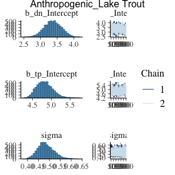

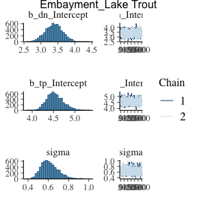

```r
m1 %>%
  iwalk(~ {
    plot(.x)
    grid.text(.y, x = 0.50, y = 0.98)
  })
```

We can see that the trace plots look “grassy” meaning the model is converging!

## Posterior draws - multiple groups

Let’s again look at the summary output from the model.

```r
m1
```

```
#> $`Anthropogenic_Lake Trout`
#>  Family: gaussian
#>   Links: mu = identity; sigma = identity
#> Formula: d15n ~ n1 + dn * (tp - l1)
#>          dn ~ 1
#>          tp ~ 1
#>    Data: .x (Number of observations: 87)
#>   Draws: 2 chains, each with iter = 4000; warmup = 1000; thin = 1;
#>          total post-warmup draws = 6000
#>
#> Regression Coefficients:
#>              Estimate Est.Error l-95% CI u-95% CI Rhat Bulk_ESS Tail_ESS
#> dn_Intercept     3.37      0.25     2.87     3.86 1.00     1683     2100
#> tp_Intercept     4.83      0.22     4.45     5.29 1.00     1686     2044
#>
#> Further Distributional Parameters:
#>       Estimate Est.Error l-95% CI u-95% CI Rhat Bulk_ESS Tail_ESS
#> sigma     0.48      0.04     0.42     0.56 1.00     2459     2350
#>
#> Draws were sampled using sampling(NUTS). For each parameter, Bulk_ESS
#> and Tail_ESS are effective sample size measures, and Rhat is the potential
#> scale reduction factor on split chains (at convergence, Rhat = 1).
#>
#> $`Embayment_Lake Trout`
#>  Family: gaussian
#>   Links: mu = identity; sigma = identity
#> Formula: d15n ~ n1 + dn * (tp - l1)
#>          dn ~ 1
#>          tp ~ 1
#>    Data: .x (Number of observations: 30)
#>   Draws: 2 chains, each with iter = 4000; warmup = 1000; thin = 1;
#>          total post-warmup draws = 6000
#>
#> Regression Coefficients:
#>              Estimate Est.Error l-95% CI u-95% CI Rhat Bulk_ESS Tail_ESS
#> dn_Intercept     3.38      0.25     2.90     3.87 1.00     1435     1836
#> tp_Intercept     4.54      0.19     4.20     4.95 1.00     1430     1885
#>
#> Further Distributional Parameters:
#>       Estimate Est.Error l-95% CI u-95% CI Rhat Bulk_ESS Tail_ESS
#> sigma     0.61      0.08     0.48     0.80 1.00     2097     1929
#>
#> Draws were sampled using sampling(NUTS). For each parameter, Bulk_ESS
#> and Tail_ESS are effective sample size measures, and Rhat is the potential
#> scale reduction factor on split chains (at convergence, Rhat = 1).
```

## Predictive posterior check

We can check how well the model is predicting the $\delta^{15}N$ of the consumer using `pp_check()` from `{bayesplot}`. We have to use `map()` from `{purrr}` to iterate over the list that has our model objects.

```
#> Using 10 posterior draws for ppc type 'dens_overlay' by default.
#> Using 10 posterior draws for ppc type 'dens_overlay' by default.
#> $`Anthropogenic_Lake Trout`
```

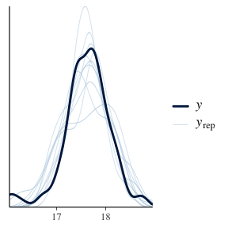

```
#>
#> $`Embayment_Lake Trout`
```

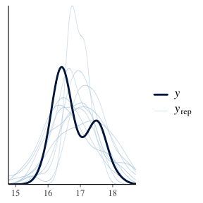

```r
m1 %>%
  map(~ .x %>%
        pp_check()
  )
```

We can see that posteriors draws ($y_{rep}$; light lines) for both groups are are effectively modeling $\delta^{15}N$ of the consumer ( $y$; dark line).

## Extract posterior draws - multiple groups

We use functions from [{tidybayes}](http://mjskay.github.io/tidybayes/) to do this work. First we look at the the names of the variables we want to extract using `get_variables()`. Considering we have multiple models in `m1` that all have the same structure, we can just look at the names of the first model object in `m1`.

```r
get_variables(m1[[1]])
```

```
#>  [1] "b_dn_Intercept" "b_tp_Intercept" "sigma"          "lprior"         "lp__"           "accept_stat__"  "stepsize__"     "treedepth__"    "n_leapfrog__"
#> [10] "divergent__"    "energy__"
```

You will notice that `"b_tp_Intercept"` is the name of the variable that we are wanting to extract. Next we extract posterior draws using `gather_draws()`, and rename `"b_tp_Intercept"` to `tp`.

Again, considering we have multiple models in `m1` we need to use `map()` to iterate over `m1` to get the posterior draws. Once we have iterated over `m1` to extract draws we can combine the results using `bind_rows()` from [{dplyr}](https://dplyr.tidyverse.org/). The variable `name` will have the name of the ecoregion and common name of the species pasted to together by a `_`. We need to separate this string into the two variables we want, being `ecoregion` and `common_name`. We can do this by using `separate_wider_delim()` from [{tidyr}](https://tidyr.tidyverse.org/). When using this function it will separate the columns and keep them as `characters`, hence why the last step is to convert `ecoregion` into a `factor`.

For your data you will likely have category names other than `ecoregion` and `common_name`. Please replace with the columns that fit your data structure.

```r
post_draws_mg <- m1 %>%
  map(~ .x %>%
        gather_draws(b_tp_Intercept) %>%
        mutate(
          .variable = "tp"
        ) %>%
        ungroup()
  ) %>%
  bind_rows(.id = "name") %>%
  separate_wider_delim(name, names = c("ecoregion", "common_name"),
                       delim = "_", cols_remove = FALSE) %>%
  mutate(
    ecoregion = factor(ecoregion,
                       levels = c("Anthropogenic", "Embayment")),
  )
```

Let’s view the `post_draws_mg`

```r
post_draws_mg
```

```
#> # A tibble: 12,000 × 8
#>    ecoregion     common_name name                     .chain .iteration .draw .variable .value
#>    <fct>         <chr>       <chr>                     <int>      <int> <int> <chr>      <dbl>
#>  1 Anthropogenic Lake Trout  Anthropogenic_Lake Trout      1          1     1 tp          4.87
#>  2 Anthropogenic Lake Trout  Anthropogenic_Lake Trout      1          2     2 tp          4.84
#>  3 Anthropogenic Lake Trout  Anthropogenic_Lake Trout      1          3     3 tp          4.72
#>  4 Anthropogenic Lake Trout  Anthropogenic_Lake Trout      1          4     4 tp          4.80
#>  5 Anthropogenic Lake Trout  Anthropogenic_Lake Trout      1          5     5 tp          4.60
#>  6 Anthropogenic Lake Trout  Anthropogenic_Lake Trout      1          6     6 tp          4.56
#>  7 Anthropogenic Lake Trout  Anthropogenic_Lake Trout      1          7     7 tp          5.05
#>  8 Anthropogenic Lake Trout  Anthropogenic_Lake Trout      1          8     8 tp          4.87
#>  9 Anthropogenic Lake Trout  Anthropogenic_Lake Trout      1          9     9 tp          4.91
#> 10 Anthropogenic Lake Trout  Anthropogenic_Lake Trout      1         10    10 tp          4.81
#> # ℹ 11,990 more rows
```

1. `ecoregion`
2. `common_name`
3. `.chain`
4. `.iteration` (number of samples after burn-in)
5. `.draw` (number of samples from `iter`)
6. `.variable` (this will have different variables depending on what is supplied to `gather_draws()`)
7. `.value` (estimated value)

Note - the names of and items in the first two columns will vary depending on the names you split your data into.

## Extracting credible intervals - multiple groups

Considering we are likely using this information for a paper or presentation, it is nice to be able to report the median and credible intervals (e.g., equal-tailed intervals; ETI). We can extract and export these values using `spread_draws()` and `median_qi` from [{tidybayes}](http://mjskay.github.io/tidybayes/).

Again, because `m1` is a `list` of our model objects, we need to `map()` over the list to calculate these values. Then we do the same procedures we have done before to combine and restructure the outputs. Lastly, we use `mutate_if()` to round all columns that are numeric to two decimal points.

```r
post_medians_ci <- m1 %>%
  map(~ .x %>%
        spread_draws(b_tp_Intercept) %>%
        median_qi() %>%
        rename(
          tp = b_tp_Intercept
        )
  ) %>%
  bind_rows(.id = "name") %>%
  separate_wider_delim(name, names = c("ecoregion", "common_name"),
                       delim = "_", cols_remove = FALSE) %>%
  mutate(
    ecoregion = factor(ecoregion,
                       levels = c("Anthropogenic", "Embayment")),
  ) %>%
  mutate_if(is.numeric, round, digits = 2)
```

Let’s view the output.

```r
post_medians_ci
```

```
#> # A tibble: 2 × 9
#>   ecoregion     common_name name                        tp .lower .upper .width .point .interval
#>   <fct>         <chr>       <chr>                    <dbl>  <dbl>  <dbl>  <dbl> <chr>  <chr>
#> 1 Anthropogenic Lake Trout  Anthropogenic_Lake Trout  4.81   4.45   5.29   0.95 median qi
#> 2 Embayment     Lake Trout  Embayment_Lake Trout      4.52   4.2    4.95   0.95 median qi
```

I like to use [{openxlsx}](https://ycphs.github.io/openxlsx/index.html) to export these values into a table that I can use for presentations and papers. For the vignette I am not going to demonstrate how to do this but please check out `{openxlsx}`.

## Plotting posterior distributions - multiple groups

Now that we have our posterior draws extracted we can plot them. For comparing trophic position among species or groups, I like using either violin plots, interval points, or slab plots for posteriors. We can access violins through [{ggplot2}](https://ggplot2.tidyverse.org/) with the later being available in [{ggdist}](https://mjskay.github.io/ggdist/).

### Violin plot

Let’s first look at the violin plot.

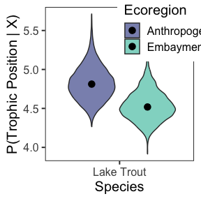

```r
ggplot(data = post_draws_mg, aes(x = common_name,
                                 y = .value,
                                 fill = ecoregion)) +
  geom_violin() +
  stat_summary(fun = median, geom = "point",
               size = 3,
               position = position_dodge(0.9)
  ) +
  scale_fill_viridis_d(name = "Ecoregion",
                       option = "G",
                       begin = 0.35,
                       end = 0.75, alpha = 0.65) +
  theme_bw(base_size = 15) +
  theme(
    panel.grid = element_blank(),
    legend.position = "inside",
    legend.position.inside = c(0.85, 0.86)
  ) +
  labs(
    x = "Species",
    y = "P(Trophic Position | X)"
  )
```

### Point interval plot

Next, we’ll look at the point interval plot – but first we need to create our colour palette.

```r
viridis_colours <- viridis(2,
                           option = "G",
                           begin = 0.35,
                           end = 0.75,
                           alpha = 0.65)
```

Now let’s plot the point intervals.

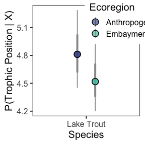

```r
ggplot(data = post_draws_mg, aes(x = common_name,
                                 y = .value,
                                 group = ecoregion)) +
  stat_pointinterval(
    aes(point_fill = ecoregion),
    point_size = 4,
    interval_colour = "grey60",
    position = position_dodge(0.4),
    shape = 21,
  ) +
  scale_fill_manual(aesthetics = "point_fill",
                    values = viridis_colours,
                    name = "Ecoregion") +
  theme_bw(base_size = 15) +
  theme(
    panel.grid = element_blank(),
    legend.position = "inside",
    legend.position.inside = c(0.85, 0.86)
  ) +
  labs(
    x = "Species",
    y = "P(Trophic Position | X)"
  )
```

Congratulations we have successfully run a Bayesian one source trophic position model for one species in two ecoregions of Lake Ontario!